# Burlington Fire Department Incidents & Response Times, 2018 - 2019

Clay Crisholm, Ethan Lauricella & Lucía Carrera

10/17/2021

## Introduction

The data set we are analyzing today is based on data from the Burlington Fire Department. This data includes info on incident types and response times from Aug 1, 2018, through November 30, 2019. Data was pulled from the fire department RMS database. There is no sample bias as the data is strictly incident responses of the fire department. This data is an observational study to see the time taken from call to response of the fire department and locations of incidents. The only bias that is seen is possibility in rounding times to the nearest minute, but this is understandable and would not affect the results.

We believe this data could be very interesting to understand for what reasons the population of Burlington most frequently call the fire department, as well as, the efficiency and speed that they have. Because this city has a large population of students we are also intrigued to see if the large influx of college students during the fall and spring semester change the data, for example: the reasons for the calls and the times these emergencies occur. Another factor we believe could strong affect our data would be the winter season, as Vermont is known for being very cold, this could change the reasons to why the fire department was called.

To be able to use this data set we had to do some cleaning: the most important part was to change the names of our variables due to them being very long and incomprehensible. We also modified the geopoint column by separating and creating two new variables, Longitude and Latitude. This was done to be able to use Leaflet to plot coordinates.

## Data Background

```r
knitr::opts_chunk$set(echo = TRUE)

# Loading of packages we will use for our project
library(tidyverse)
library(lubridate)
library(leaflet)
library(gridExtra)

# Loading of the data frame fire to use
fire <- read.csv("O_fire_new.csv", na.strings = '', stringsAsFactors = TRUE)

# Result summaries of our data
tibble(fire)
```

```
## # A tibble: 10,954 x 14
##    District      Unit  Inci_no  incid_descrip Alm_d..m Disp_d....m No..if_d....m
##    <fct>         <fct> <fct>    <fct>         <fct>    <fct>       <fct>
##  1 New North End A2    19-0002~ EMS call      5/3/19 ~ 5/3/19 17:~ 5/3/19 17:15
##  2 New North End A2    19-0002~ EMS call      5/9/19 ~ 5/9/19 6:45 5/9/19 6:47
##  3 New North End A2    19-0002~ EMS call      5/9/19 ~ 5/9/19 10:~ 5/9/19 10:36
##  4 Hill Section  A1    18-0005~ EMS call      9/16/18~ 9/16/18 16~ 9/16/18 16:42
##  5 SB            A1    18-0005~ EMS call      9/12/18~ 9/12/18 9:~ 9/12/18 9:14
##  6 Downtown      R1    19-0006~ EMS call      10/24/1~ 10/24/19 9~ 10/24/19 9:41
##  7 Hill Section  R1    19-0006~ Smoke scare,~ 10/24/1~ 10/24/19 1~ 10/24/19 11:~
##  8 Hill Section  R1    19-0007~ Alarm system~ 11/13/1~ 11/13/19 1~ 11/13/19 13:~
##  9 Downtown      R1    19-0007~ Assist inval~ 11/26/1~ 11/26/19 2~ 11/26/19 21:~
## 10 Downtown      R1    19-0006~ EMS call      10/14/1~ 10/14/19 1~ 10/14/19 10:~
## # ... with 10,944 more rows, and 7 more variables: Roll_d....m <fct>,
## #   Arv_d....m <fct>, In_d....m <fct>, City <fct>, Zip <int>, Shift <fct>,
## #   geopoint <fct>
```

```r
# Visualization of the different variables available in our data set
names(fire)
```

```
##  [1] "District"      "Unit"          "Inci_no"       "incid_descrip"
##  [5] "Alm_d..m"      "Disp_d....m"   "No..if_d....m" "Roll_d....m"
##  [9] "Arv_d....m"    "In_d....m"     "City"          "Zip"
## [13] "Shift"         "geopoint"
```

```r
## The names of our variables were summarized by r studio leading to names such as "Disp_d....m", to be able to clearly use our data we decided to modify these names for ease of use.

# Incident number
names(fire)[3] <- "Inc_num"

# Incident description
names(fire)[4] <- "Inc_des"

# Alarm date and time
names(fire)[5] <- "Alm_dt"

# Dispatch date and time
names(fire)[6] <- "Dis_dt"

# Dispatch Notified Date and Time
names(fire)[7] <- "Not_dt"

# Unit responding Date and Time
names(fire)[8] <- "Roll_dt"

# Arrival Date and Time
names(fire)[9] <- "Arv_dt"

# In Service Time
names(fire)[10] <- "Ins_dt"


##  We decided to add lattitude and longitude columns
fire <- fire %>% mutate(geopoint2 = str_sub(geopoint, 1,-1)) %>%
  separate(geopoint2, into = c('Lat', 'Long'), sep = ',')

fire <- fire %>% mutate(Long = as.numeric(Long), Lat =as.numeric(Lat))

names(fire)
```

```
##  [1] "District" "Unit"     "Inc_num"  "Inc_des"  "Alm_dt"   "Dis_dt"
##  [7] "Not_dt"   "Roll_dt"  "Arv_dt"   "Ins_dt"   "City"     "Zip"
## [13] "Shift"    "geopoint" "Lat"      "Long"
```

The graph below is a histogram to represent what hour of the day most calls come in. According to the graph, the most likely times are between hours 5 and 15 on a 24 hour scale. There is a peak between the 11th and 12th hour and a dip between 20 and 5. Because this is 24 hour scale we can say the dip is between 20 and 5.

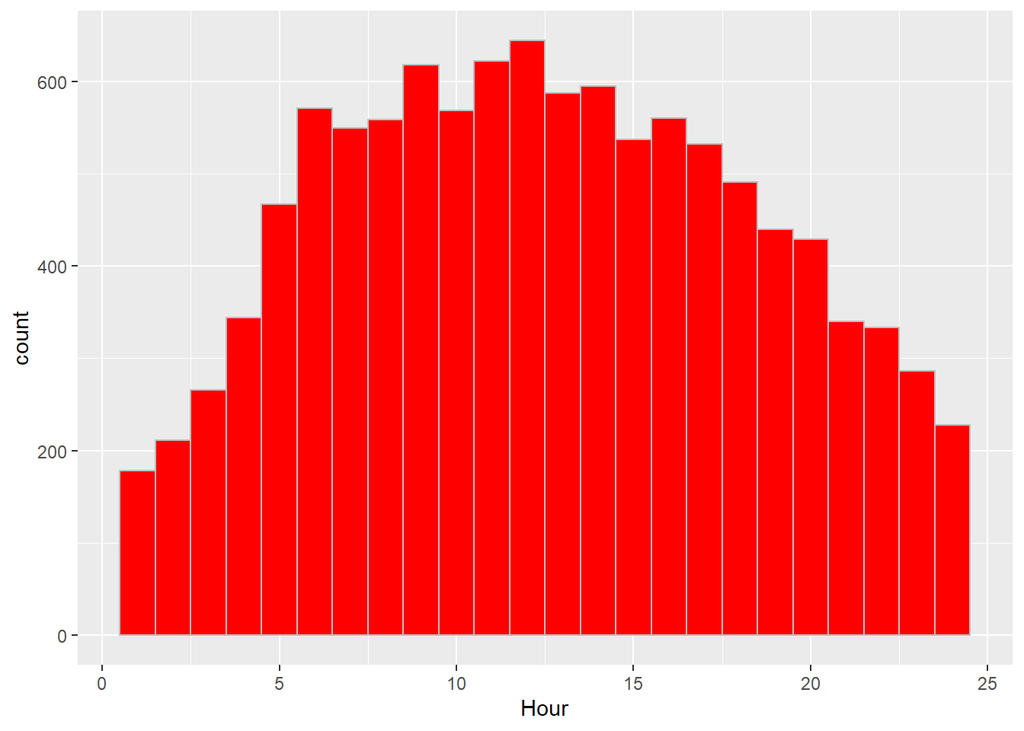

```r
# The first graph we wanted to map out is the time of calls to see at what were the most "popular" times to call
alarm <- fire %>% mutate(Call = mdy_hm(Alm_dt),
                   Weekday = wday(Call, label = TRUE),
                   Mon = month(Call, label = TRUE),
                   Date = date(Call),
                   Hour = hour(Call) + 1)

#
ggplot(data = alarm,
       mapping = aes(x= Hour)) +
  geom_histogram(binwidth = 1, color = 'grey', fill = 'red')
```

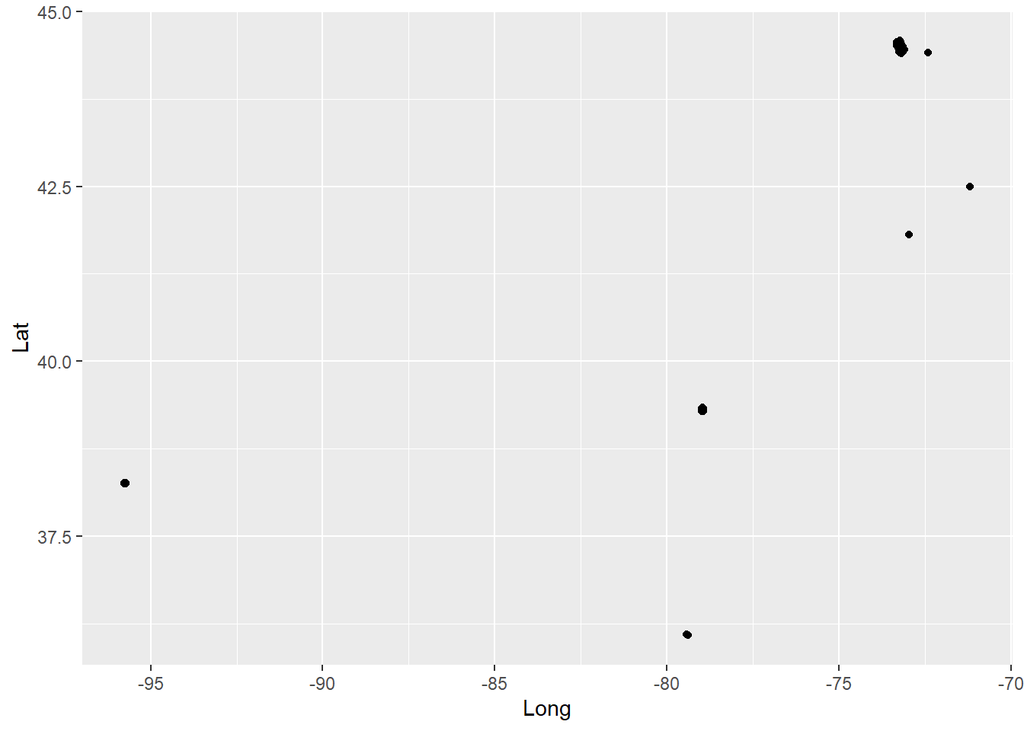

```r
#  Do a scatterplot of Latitude by Longitude, to see where calls are made in Burlington. Do you recognize the shape of the data?

# no


# Location of Calls
ggplot(data = fire,
mapping = aes(x = Long, y = Lat )) +
  geom_point()
```

```r
#  Using leaflet, make a map showing circles on the location of each incident.  Start here:
m <- leaflet() %>%
  addTiles() %>%
  setView(lat = 44.475, lng = -73.212, zoom = 12)

#  (Once you get the leaflet plot working, remove the scatterplot of Longitude by Latitude)
m  %>% addCircles(lng = fire$Long, lat = fire$Lat)
```

[interactive chart not shown]

```r
f2 <- fire %>% group_by(Unit) %>% summarize(count = n()) %>% arrange(desc(count)) %>% select(Unit = Unit, count = count)
f2
```

```
## # A tibble: 37 x 2
##    Unit  count
##    <fct> <int>
##  1 E1     2200
##  2 E3     1434
##  3 T1     1127
##  4 L4     1118
##  5 L2     1072
##  6 A2      971
##  7 E5      690
##  8 A1      631
##  9 E6      532
## 10 BATT1   388
## # ... with 27 more rows
```

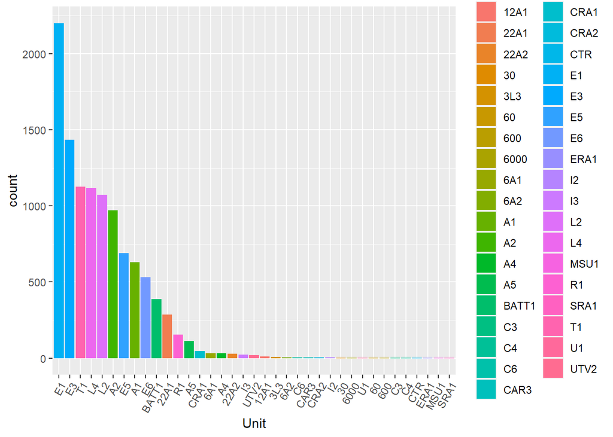

```r
ggplot(data = fire, mapping = aes(x = Unit, fill = Unit) )+
  geom_bar()+ theme(axis.text.x = element_text(hjust=1, angle = 60)) +
  scale_x_discrete(limits = f2$Unit)
```

### Type of incident description

This shows the amount of what type of incidents the fire department responds to. Most of their responses involve EMS calls. (If you can suggest a fix for the labels that would be great as they are currently too long and cause issues)

```r
incident <- fire %>% group_by(Inc_des) %>% summarize(count = n()) %>% select(Inc_des = Inc_des, count = count) %>% arrange(desc(count)) %>% filter(count > 90)
incident
```

```
## # A tibble: 11 x 2
##    Inc_des                                                                 count
##    <fct>                                                                   <int>
##  1 EMS call                                                                 6551
##  2 EMS call where injured party has been transported by a non-fire servic~   590
##  3 Smoke detector activation (no fire), unintentional                        550
##  4 Smoke detector activation due to malfunction                              396
##  5 Assist invalid                                                            350
##  6 Good intent call, other                                                   222
##  7 Alarm system activation due to malfunction                                183
##  8 Motor vehicle accident with no injuries                                   146
##  9 No incident found on arrival at dispatch address                          118
## 10 Motor vehicle accident with injuries                                      104
## 11 Alarm system activation (no fire), unintentional                           91
```

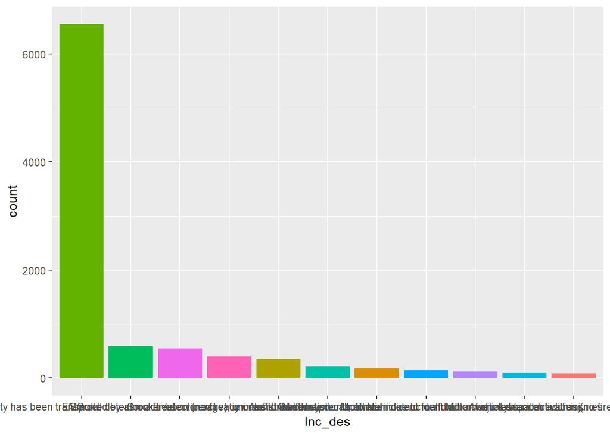

```r
ggplot(data = fire, mapping = aes(x = Inc_des, fill = Inc_des))+
  geom_bar()+#theme(axis.text.x = element_text(hjust=1, angle = 60))+
  scale_x_discrete(limits = incident$Inc_des)+theme(legend.position = 'none') # Idk how else to hide the key
```

### Month by shifts

```r
shift_time <- fire %>% filter(!is.na(Shift)) %>% mutate(Call = mdy_hm(Dis_dt),
                   Weekday = wday(Call, label = TRUE),
                   Mon = month(Call, label = FALSE),
                   Date = date(Call),
                   Hour = hour(Call))
names(shift_time)
```

```
##  [1] "District" "Unit"     "Inc_num"  "Inc_des"  "Alm_dt"   "Dis_dt"
##  [7] "Not_dt"   "Roll_dt"  "Arv_dt"   "Ins_dt"   "City"     "Zip"
## [13] "Shift"    "geopoint" "Lat"      "Long"     "Call"     "Weekday"
## [19] "Mon"      "Date"     "Hour"
```

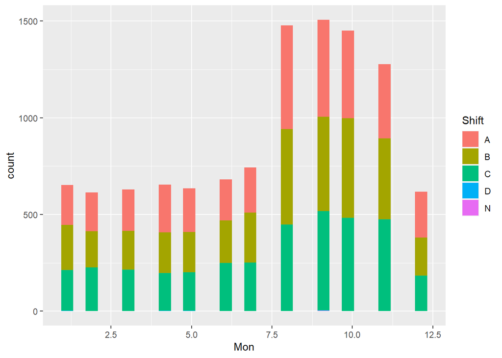

```r
ggplot(data = shift_time, mapping = aes(x= Mon, fill = Shift))+
  geom_histogram()
```

This plot shows the time spent at each incident in minutes. Most incidents only take about 20 minutes at the site. There is some cases where the shift is needed at a site for a long time. Most incidents are EMS calls, thus this makes sense as they most likely arrive at the scene and call for an ambulence to deliver the patient to a medical facility.

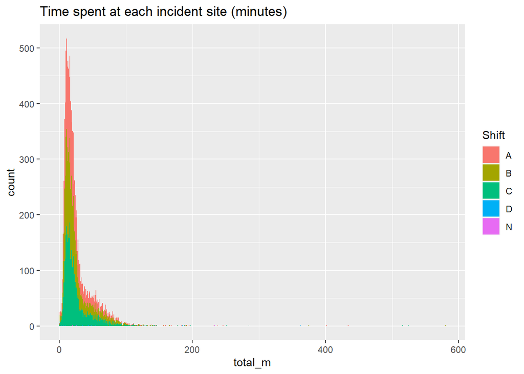

```r
# Time spent at each site, A_ being the arrival time, and D_ being the departure time

inc_time <- fire %>% filter(!is.na(Alm_dt)) %>% filter(!is.na(Inc_des)) %>%
                    mutate(ACall = mdy_hm(Alm_dt),
                   AWeekday = wday(ACall, label = TRUE),
                   AMon = month(ACall, label = TRUE),
                   ADate = date(ACall),
                   AHour = hour(ACall),
                   AMin = minute(ACall)) %>%
                    mutate(DCall = mdy_hm(Ins_dt),
                   DWeekday = wday(DCall, label = TRUE),
                   DMon = month(DCall, label = TRUE),
                   DDate = date(DCall),
                   DHour = hour(DCall),
                   DMin = minute(DCall))

inc_time <- inc_time %>% mutate(
                            time_workd = (DDate - ADate)*24*60,
                            time_workh = (DHour - AHour)*60,
                            time_workm = DMin - AMin,
                            total_m = time_workh + time_workm + time_workd)

inc_time <- inc_time %>% filter(!is.na(inc_time))


ggplot(data = inc_time, mapping = aes(x= total_m, fill = Shift))+
  geom_histogram(binwidth = 1) + labs(title = "Time spent at each incident site (minutes)")
```